# REDWINE ANALYSIS

## PLOTTING THE RESIDUALS

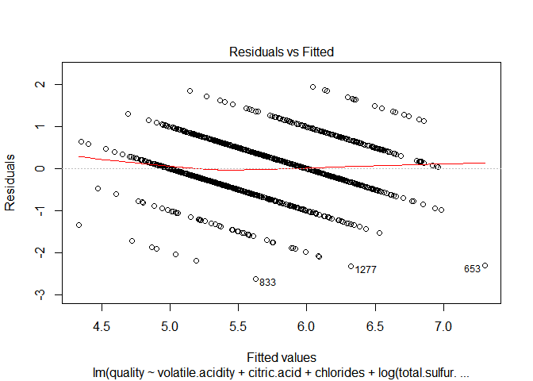

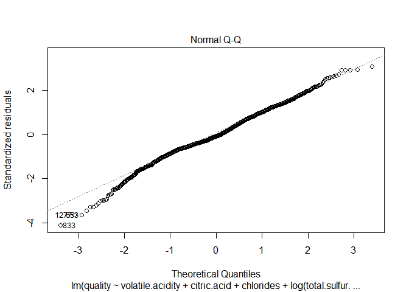

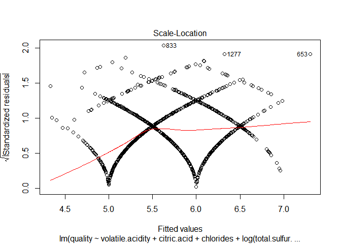

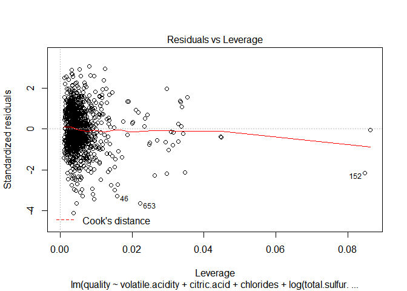

From the plot 2 we can see that the observation lie around the 45 degree line and hence we can assume that the normality holds true in this case.

## PREDICTION using test data

```
## [1] "Estimator Output: 5"
```

```
## [1] "Actual Output: 5"
```

# MULTI-VARIATE ANALYSIS

The analysis are inferences from each of the plot segment is mentioned under the plot.Also a Linear model has been built based on the data provided. There have been really surprising corelations that can be observed from the plots and from the significance indicated in the model.The density,residula sugar and fixed acidity do not seem to play an important role in determinig the quality however the exploratory data did show some relation

The model was initially built using all the variables and was further tuned to consider only the significant variables. Limitations:The training :test ratio for building the model was 90%:10% since the number of data points were limited.Hence there is a possibility of overfitting in the data

# FINAL PLOTS AND SUMMARY

Below are some of the final plots chosen which provide significant relationship among the variables.

### Plot One

SO2 and Quality

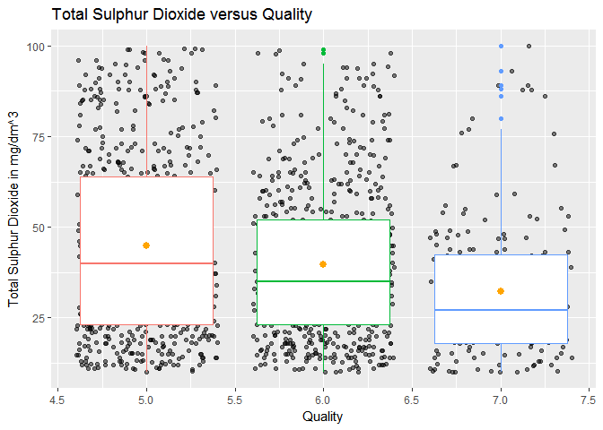

### Description 1:

The above plot shows the clear realtion between Total SO2 Content(y axis) and Quality(X axis).The higher the SO2 content the lower is the rated quality. So2 is used a necessary preservative however at higher levels it affects the taste and emits a not so good smell bringing down the quality

### Plot Two

Acidity and citric Acid and Quality

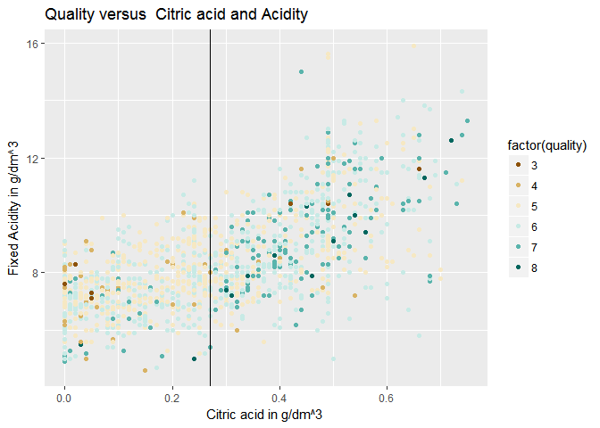

### Description 2:

Citric acid(X-axis) has a positive corelation with fixed acidity(y-axis) since it is a part of acidity value. Just a casual observation will lead to make us believe that the better quality wines have a higher fixed acidity ,but this is mostly because of a higher citric acid presence with most of the high rated wines having a citric acid content of over 0.27

### Plot 3

Alcohol -Density-Quality

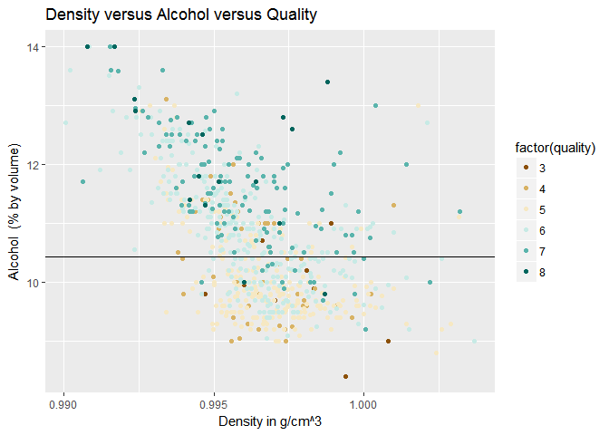

### Description 3:

The above plot shows the realtionship between alcohol(y axis) ,density(x axix) and quality(3rd dimension in coloured points) We can see a inverse relation between alcohol and density and also a positive corelation between higher quality and higher alcohol content can be observed which indicates that most of the highly rated alcohols had a higher alcohol content.

# REFLECTION

The Data set was fairly small with a limited set of attributes. The dataset is quite clean which was easy in getting started with the analysis.

Surprise points: There were some variables(citric acid and acidity) for which the corelation number did not reveal much but plotting them in a graph could bring in the relationship.

There were some variables(acidity/density) which seemed to have a relationship to the quality but were considered insignificant in the linear model

Some struggles/Limitations: -The data set was fairly small and also the samples for quality rating of 3 and 8 were too less so the presence in the point graphs could not be felt to make appropriate conclusions and more dependency was on quality grade of 4-7 which is mostly hovering around the mean quality.

- On the multivariate plots,plotting the variable was ok but deriving meaningful inference was a bit difficult
- Also felt the lack of domain knowledge/chemistry to my disadvantage

Future Possible explorations: New features can be formed based on the realtionship and interaction between the variables like(citric acid and acidity) or pH and acidity or sulpahtes and SO2 -how each of the variable is dependent upon the other and the rate a which it is affected. This would in turn help fine tuning the linear model for a better fit to the data.